# Data visualization: UMAP

24 November 2021

## Practical Session UMAP

Please, complete all the code proposed and answer to questions.

You will find these on the slides as (#) and (Q). You are not expected to include your answer to the check questions (C) or (K) knowledge thoughts. These are only to guide your progress.

Change the code appropriately or add new lines if necessary.

## Load some functions and init variables

```r
library(ggplot2)
library(umap)
library(Rtsne)

plot_representation <- function(x_given, y_given, meta_data, title) {
  data_plot <- data.frame(x = x_given,
                          y = y_given,
                          col = meta_data)

  p <- ggplot(data_plot) + geom_point(aes(x=x, y=y, color=col)) +
    ggtitle(title) + theme_classic()

  return(p)
}

saved_plots <- list()
```

## Load the data

Load data into variables: Make use of any or read.delim, read.table, readlines or scan functions.

```r
# Read data
P1_data = read.delim('P1.tsv.gz', row.names = 1)
P2_data = read.delim('P2.tsv.gz', row.names = 1)

## transpose data
X1 = t(P1_data)
X2 = t(P2_data)

## Read metadata
treat <- as.factor(readLines('treatment.txt'))
```

#### Initial representation: P1 data

Create an initial representation only using `P1_data` and check items.

```r
## create UMAP
p1_dataSet_UMAP <- umap::umap(X1)

## Inspect objects and results generated
names(p1_dataSet_UMAP)
```

```
## [1] "layout" "data"   "knn"    "config"
```

```r
dim(p1_dataSet_UMAP$layout)
```

```
## [1] 96  2
```

```r
dim(p1_dataSet_UMAP$data)
```

```
## [1]    96 58441
```

```r
names(p1_dataSet_UMAP$knn)
```

```
## [1] "indexes"   "distances"
```

```r
names(p1_dataSet_UMAP$knn)
```

```
## [1] "indexes"   "distances"
```

```r
head(p1_dataSet_UMAP$knn$indexes)
```

```
##                 [,1] [,2] [,3] [,4] [,5] [,6] [,7] [,8] [,9] [,10] [,11] [,12]
## P2449_N716.S502    1    6    2    4    5    8    3   28   34    29    18    14
## P2449_N718.S502    2    5   13    6   18   15    4   20   28    29    33     3
## P2449_N719.S502    3    4    5    6   14    2   34    1   18     9    13    15
## P2449_N720.S502    4   14    3   15    5    2   18   34    6     1    13     9
## P2449_N721.S502    5    2    6    4    3   18   13   28   15    20    29    33
## P2449_N722.S502    6    5    2    3    1    4   13   29   12    20    18    28
##                 [,13] [,14] [,15]
## P2449_N716.S502    13     7    12
## P2449_N718.S502     1    21    34
## P2449_N719.S502    28    40    20
## P2449_N720.S502    16    28    27
## P2449_N721.S502     1    14    21
## P2449_N722.S502    15    14    33
```

```r
dim(p1_dataSet_UMAP$knn$indexes)
```

```
## [1] 96 15
```

```r
head(p1_dataSet_UMAP$knn$distances)
```

```
##                 [,1]     [,2]     [,3]     [,4]     [,5]     [,6]     [,7]
## P2449_N716.S502    0 8647.375 9125.229 9336.623 9665.184 9803.239 9855.690
## P2449_N718.S502    0 6600.632 7803.520 7949.803 7970.321 8136.103 8243.292
## P2449_N719.S502    0 7507.288 8022.405 8149.514 8673.210 8864.533 9312.263
## P2449_N720.S502    0 7497.091 7507.288 7752.681 7789.706 8243.292 8613.544
## P2449_N721.S502    0 6600.632 7304.024 7789.706 8022.405 8504.423 8722.862
## P2449_N722.S502    0 7304.024 7949.803 8149.514 8647.375 8888.824 9272.076
##                      [,8]      [,9]     [,10]     [,11]     [,12]     [,13]
## P2449_N716.S502 10421.874 10799.564 10817.009 10824.725 10874.111 11230.530
## P2449_N718.S502  8364.736  8492.677  8539.343  8862.971  8864.533  9125.229
## P2449_N719.S502  9855.690  9888.460 10659.160 10665.615 10810.375 11206.318
## P2449_N720.S502  8832.110  8888.824  9336.623  9480.021  9745.710  9865.836
## P2449_N721.S502  8767.051  8876.677  9015.961  9421.588  9591.128  9665.184
## P2449_N722.S502  9692.391  9802.474  9851.608  9930.330  9976.657 10229.139
##                     [,14]     [,15]
## P2449_N716.S502 11308.822 11368.499
## P2449_N718.S502  9161.945  9230.995
## P2449_N719.S502 11207.746 11435.735
## P2449_N720.S502 10033.621 10278.934
## P2449_N721.S502  9730.376  9805.933
## P2449_N722.S502 10347.149 10780.314
```

```r
dim(p1_dataSet_UMAP$knn$distances)
```

```
## [1] 96 15
```

```r
names(p1_dataSet_UMAP$config)
```

```
##  [1] "n_neighbors"          "n_components"         "metric"
##  [4] "n_epochs"             "input"                "init"
##  [7] "min_dist"             "set_op_mix_ratio"     "local_connectivity"
## [10] "bandwidth"            "alpha"                "gamma"
## [13] "negative_sample_rate" "a"                    "b"
## [16] "spread"               "random_state"         "transform_state"
## [19] "knn"                  "knn_repeats"          "verbose"
## [22] "umap_learn_args"      "method"               "metric.function"
```

```r
head(p1_dataSet_UMAP$config$n_neighbors)
```

```
## [1] 15
```

```r
head(p1_dataSet_UMAP$config$min_dist)
```

```
## [1] 0.1
```

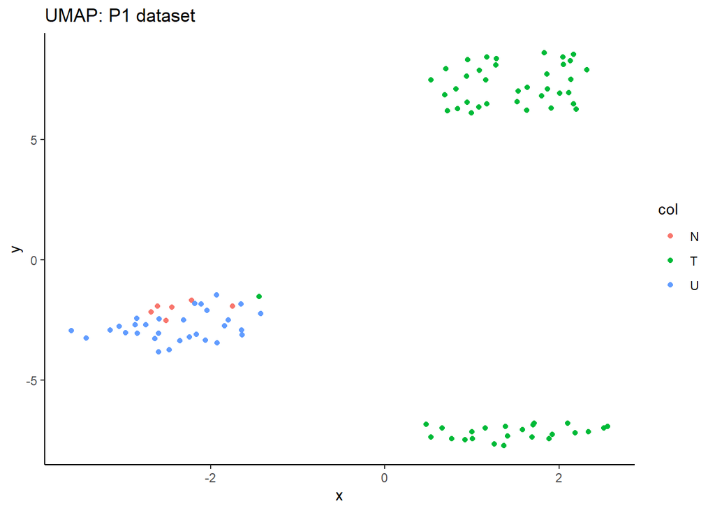

```r
## Create plot representation
UMAP_plot1 <- plot_representation(p1_dataSet_UMAP$layout[,1],
                    p1_dataSet_UMAP$layout[,2],
                    treat,
                    "UMAP: P1 dataset")

print(UMAP_plot1)
```

```r
saved_plots[['UMAP_plot1']] = UMAP_plot1
```

**Q1**. What do you think about this representation?

**A1**. We get very nice and distinct clusters, but we cannot make assumptions based on the distances between the points.

#### Add data to existing prediction

```r
dataSet_UMAP = predict(p1_dataSet_UMAP, X2)
```

Create plot:

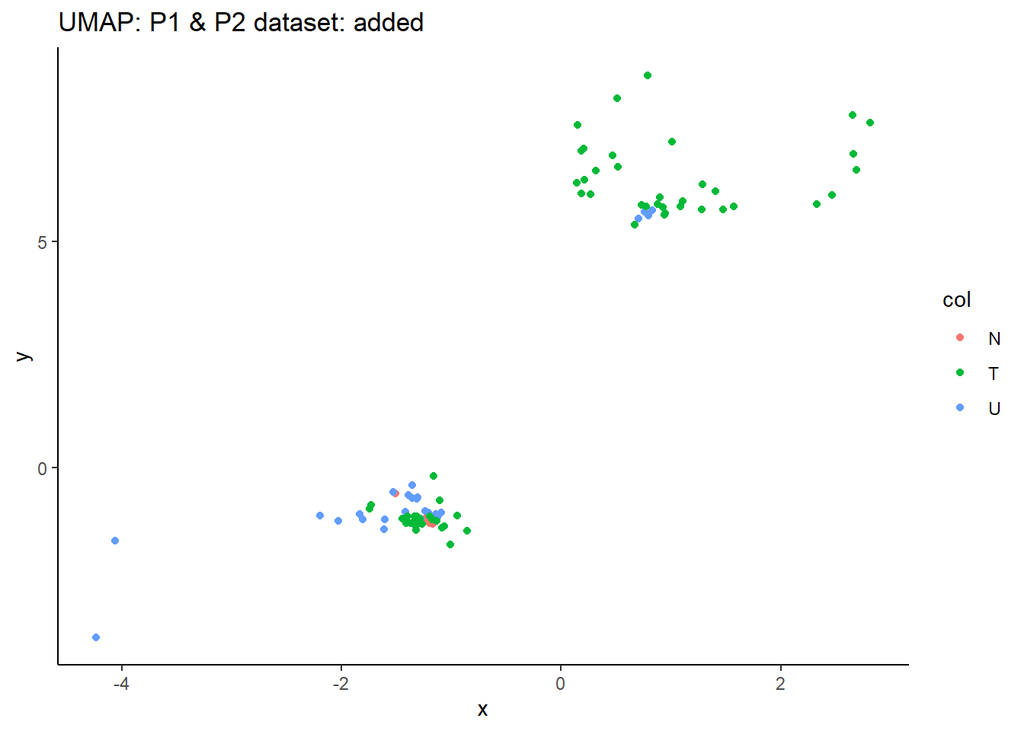

```r
## Create plot representation
UMAP_plot2 <- plot_representation(dataSet_UMAP[,1],
                    dataSet_UMAP[,2],
                    treat,
                    "UMAP: P1 & P2 dataset: added")

print(UMAP_plot2)
```

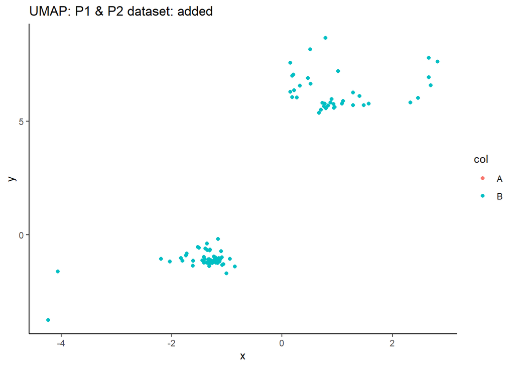

```r
saved_plots[['UMAP_plot2']] = UMAP_plot2


UMAP_plot3 <- plot_representation(dataSet_UMAP[,1],
                    dataSet_UMAP[,2],
                    as.factor(rep(c("A","B"), each=96)), ## by experiment
                    "UMAP: P1 & P2 dataset: added")
print(UMAP_plot3)
```

**Q2**. Has it changed compared to P1 data alone? What do you think about this representation?

**A2**. Yes, the resulting plot has changed, now we only obtain two unclear clusters representing the prediction of expression of our cells. We need to merge the two datasets and normalize in order to appropriately analyse the data.

### Merge data, normalize and re-run umap

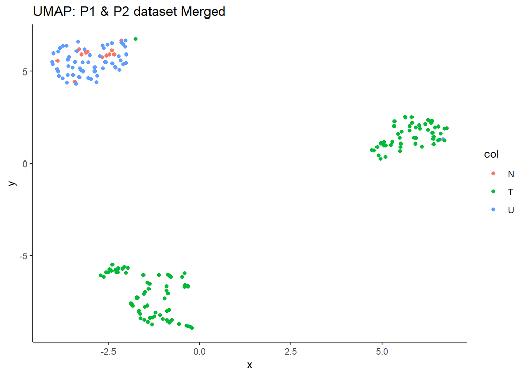

```r
# Merge replicates
X = rbind(X1,X2)
X=X[, colSums(X)>0]
Y = X/rowSums(X)

##
merge_dataSet_UMAP = umap(Y)

## Create plot representation
UMAP_plot4 <- plot_representation(merge_dataSet_UMAP$layout[,1],
                    merge_dataSet_UMAP$layout[,2],
                    treat,
                    "UMAP: P1 & P2 dataset Merged")

print(UMAP_plot4)
```

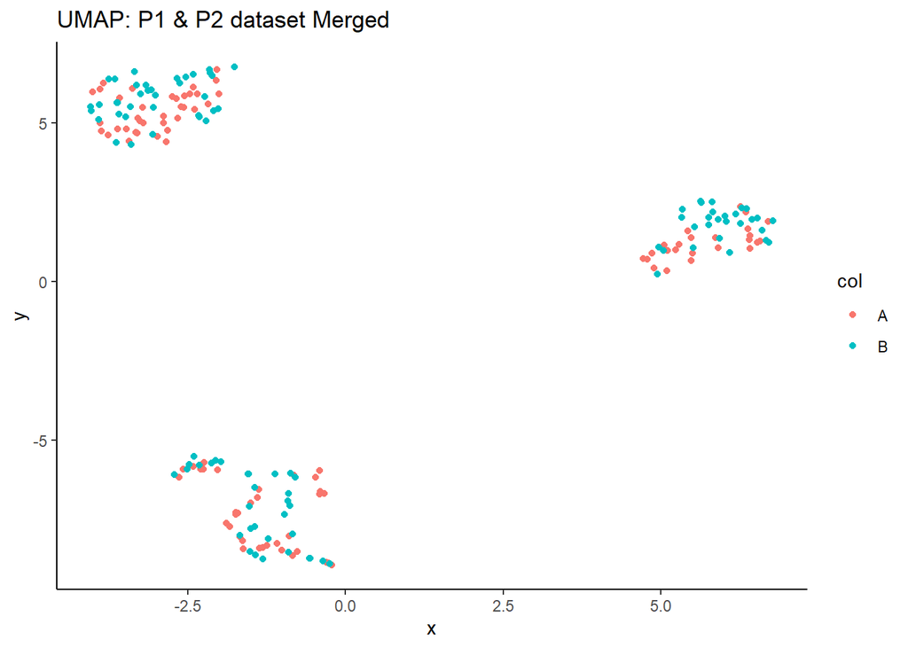

```r
saved_plots[['UMAP_plot4']] = UMAP_plot4

UMAP_plot5 <- plot_representation(merge_dataSet_UMAP$layout[,1],
                    merge_dataSet_UMAP$layout[,2],
                    as.factor(rep(c("A","B"), each=96)), ## by experiment
                    "UMAP: P1 & P2 dataset Merged")

print(UMAP_plot5)
```

```r
saved_plots[['UMAP_plot5']] = UMAP_plot5
```

**Q3**: Has it changed compared to P1 data alone or P1+P2? What do you think about this representation?

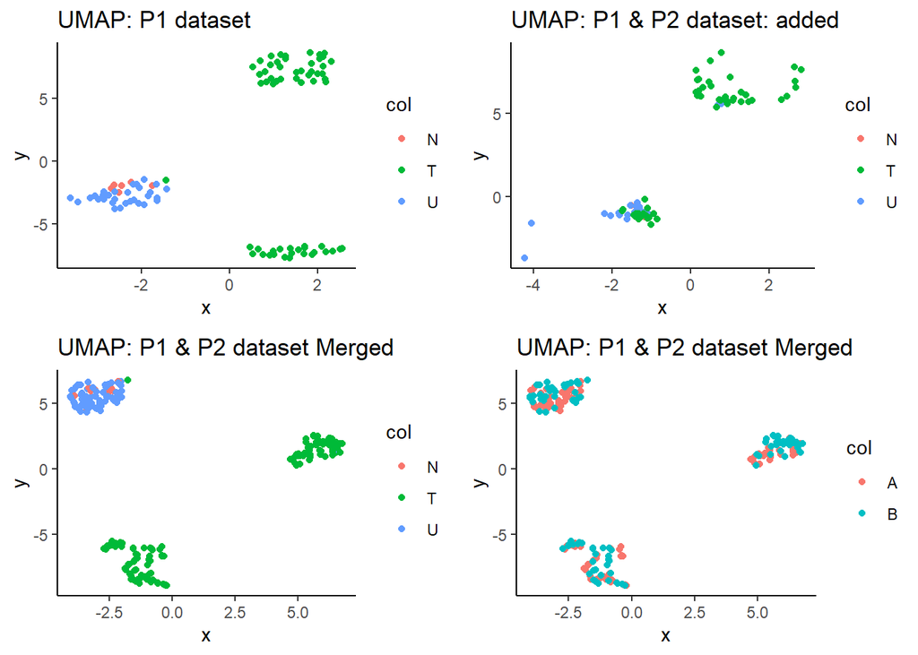

```r
library(gridExtra)
gridExtra::grid.arrange(grobs=saved_plots) ##
```

**A3**. Now that the two experiments are merged and normalized, we get a much more reasonable result, a plot where the clusters are very clearly showing how different the treated vs untreated cells are, and how different the dead and alive cells are.

#### Modify default parameters

To create a custom configuration, we can make a copy of the object and update its fields.

```r
custom.umap.config <- umap::umap.defaults
```

**Explore `n_neighbors`**:

**Q4**: What is the default value of n_neighbours?

**A4**. If we use the command `print(umap::umap.defaults)`, we get that the default value for `n_neighbours` is 15.

Create different UMAP with different `n_neighbors` values.

```
## [1] "UMAP n_neighbors=2"
```

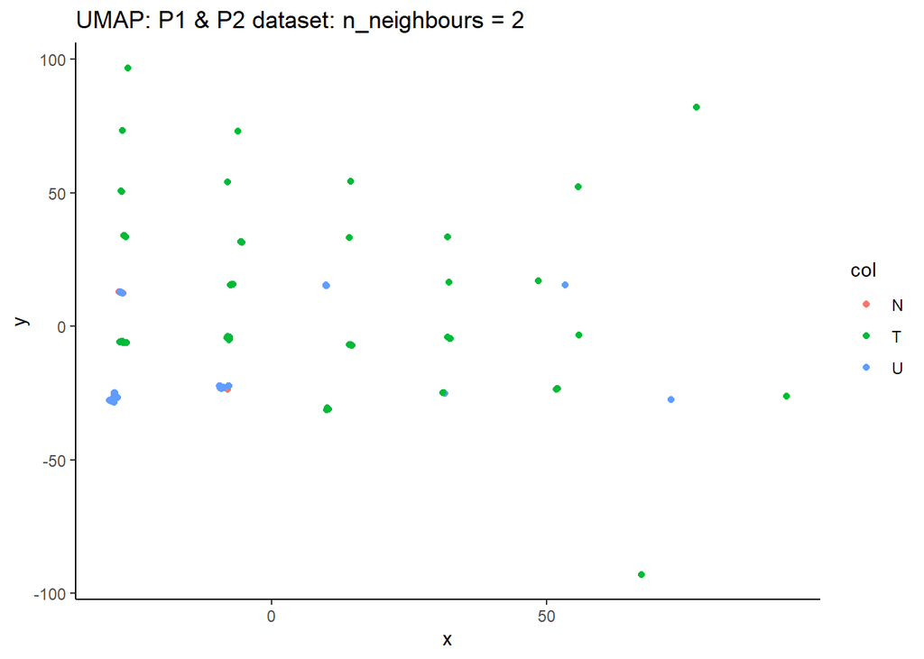

```
## [1] "UMAP n_neighbors=5"
```

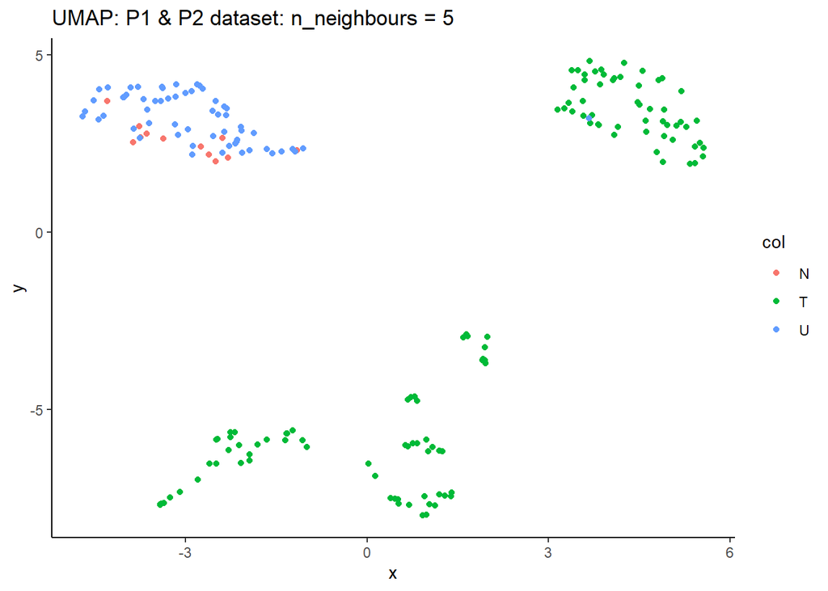

```
## [1] "UMAP n_neighbors=15"
```

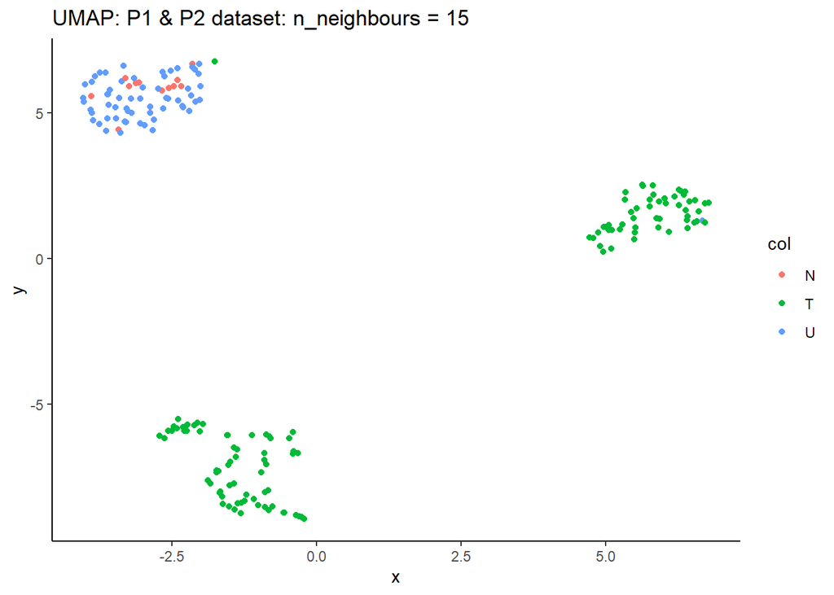

```
## [1] "UMAP n_neighbors=50"
```

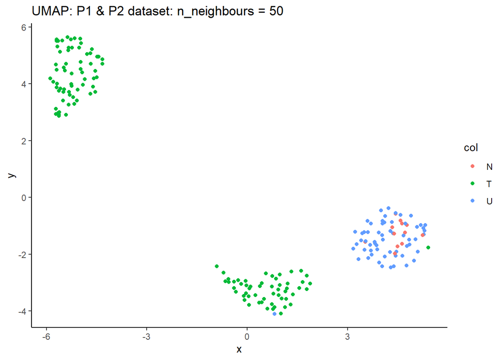

```
## [1] "UMAP n_neighbors=100"
```

```
## [1] "UMAP n_neighbors=200"
```

```
## Error: umap: number of neighbors must be smaller than number of items
```

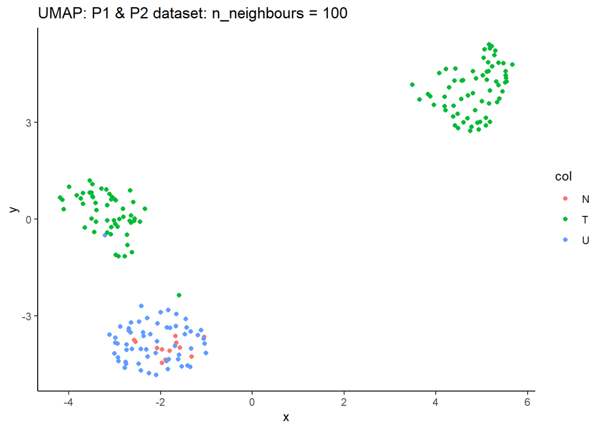

```r
list_plots <- list()

for (n_neighbors_values in c(2,5,15,50,100,200)) {
  print(paste0("UMAP n_neighbors=", n_neighbors_values))

  custom.umap.config$n_neighbors = n_neighbors_values

  umap_n <- umap(Y, config = custom.umap.config)

  UMAP_plot <- plot_representation(umap_n$layout[,1],
                    umap_n$layout[,2],
                    treat,
                    paste0("UMAP: P1 & P2 dataset: n_neighbours = ", n_neighbors_values))


  print(UMAP_plot)
}
```

**Q5**: What is the effect of modifying n_neighbours?

**A5**. The `n_neighbours` parameter specifies the number of nearest points to each of the observations in the plot. When using low values for `n_neighbours` we get many clusters containing a few points, while when using higher values, we get just a few clusters with a lot of points, almost like in the first case we are looking at the smallest differces between each observation, while in the latter case we are taking a more general view over the dataset.

**Explore `min_dist`**:

**Q6**: What is the default value of min_dist?

**A6**. The default value for `min_dist` is 0.1.

```
## [1] "UMAP min_dist=0.1"
```

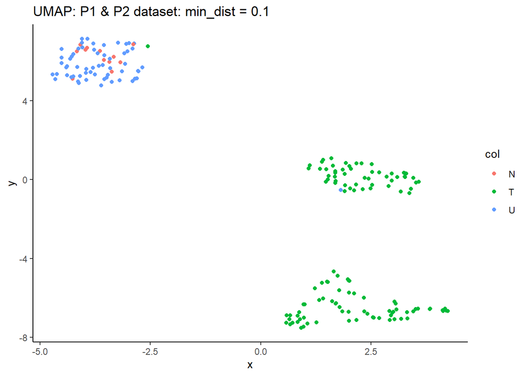

```
## [1] "UMAP min_dist=0.5"
```

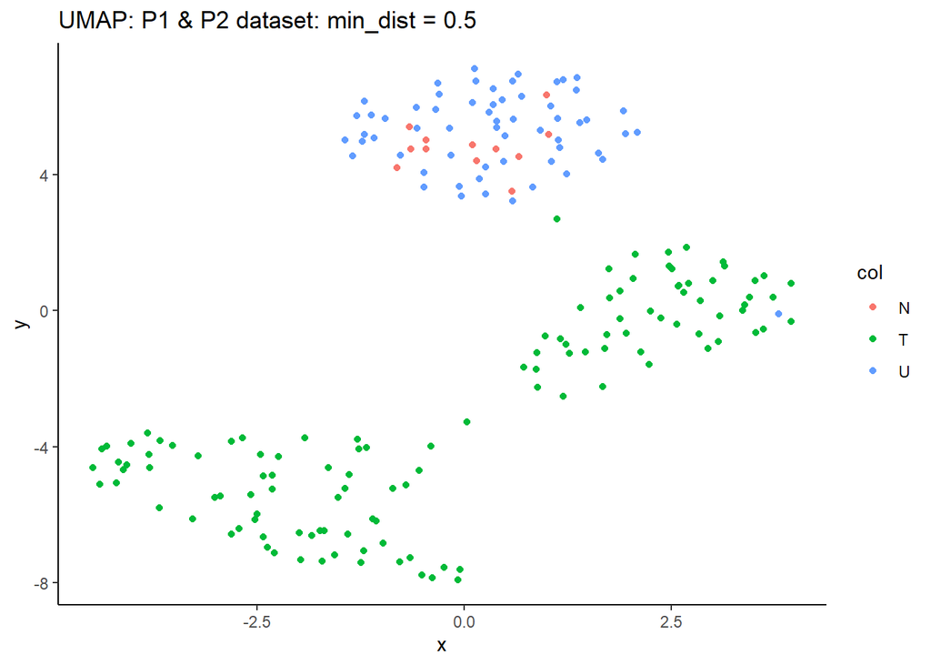

```
## [1] "UMAP min_dist=0.9"
```

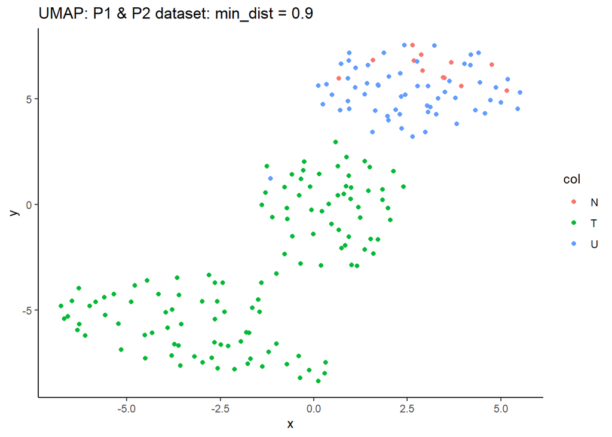

```r
list_plots2 <- list()

## set n_neighbours to default
custom.umap.config$n_neighbors = umap::umap.defaults$n_neighbors

for (min_dist_values in c(0.1,0.5,0.9)) {
  print(paste0("UMAP min_dist=", min_dist_values))

  custom.umap.config$min_dist = min_dist_values

  umap_n <- umap(Y, config = custom.umap.config)

  UMAP_plot <- plot_representation(umap_n$layout[,1],
                    umap_n$layout[,2],
                    treat,
                    paste0("UMAP: P1 & P2 dataset: min_dist = ", min_dist_values))

  print(UMAP_plot)
}
```

**Q7**: What is the effect of modifying min_dist?

**A7**. The `min_dist` parameter defines how close points appear in the layout of the plot. Low values of `min_dist` lead to more tightly packed clusters, whereas larger values will lead to more loose clusters.

# Compare performance

```r
t0 <- Sys.time()
pca_data <- prcomp(Y, scale. =TRUE)
tf <- Sys.time()
print(tf-t0)
```

```
## Time difference of 3.883068 secs
```

```r
t1 <- Sys.time()
tSNE_data <- Rtsne(Y, pca=TRUE)
tf1 <- Sys.time()
print(tf1-t1)
```

```
## Time difference of 3.674058 secs
```

```r
t2 <- Sys.time()
umap_data <- umap(Y)
tf2 <- Sys.time()
print(tf2-t2)
```

```
## Time difference of 1.745002 secs
```

**Q8**: Write some comments on the performance comparison between different techniques.

**A8**. Comparing the time performance of the three studied techniques, we get that **tSNE** is a little faster than **PCA**, but the striking fact is that **UMAP** is very much faster than both of them (basically twice as fast!), while also being able to convey very nice results.

**Q9**: Write some comments and a comparison on the plots from different techniques.

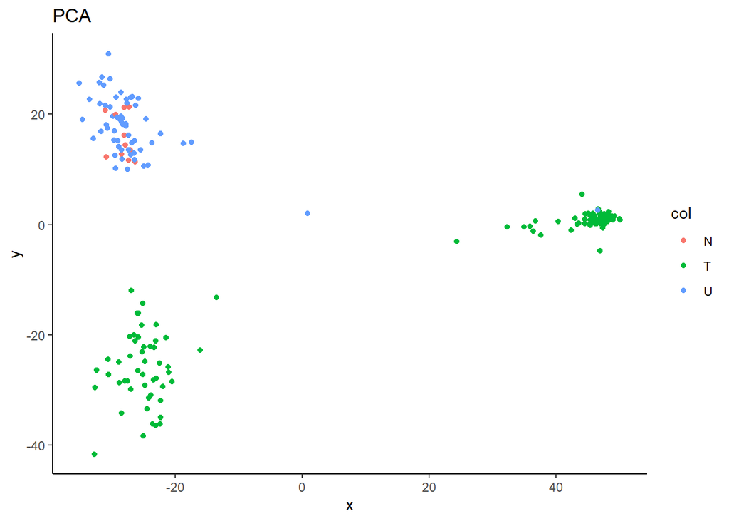

```r
pca_plot <- plot_representation(pca_data$x[,1],
                    pca_data$x[,2],  treat,
                    "PCA")

print(pca_plot)
```

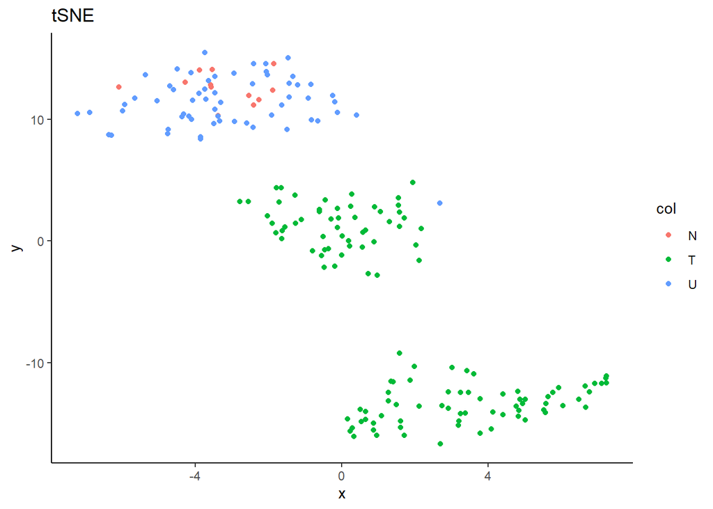

```r
tSNE_plot <- plot_representation(tSNE_data$Y[,1],
                    tSNE_data$Y[,2],  treat,
                    "tSNE")

print(tSNE_plot)
```

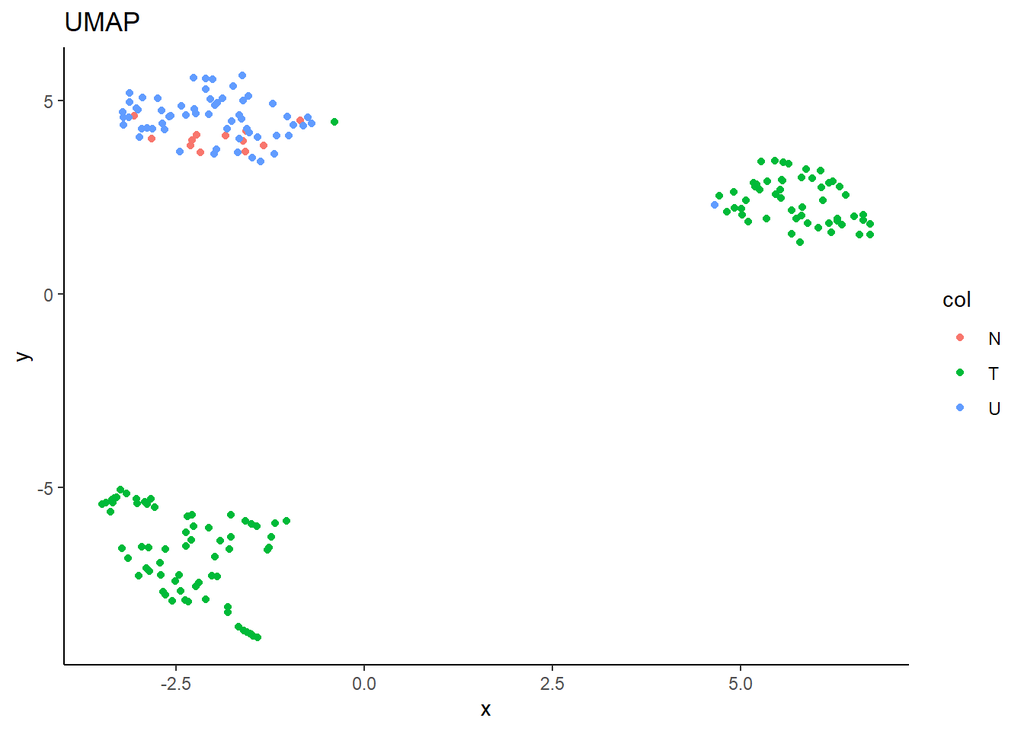

```r
UMAP_plot <- plot_representation(umap_data$layout[,1],
                    umap_data$layout[,2],  treat,
                    "UMAP")

print(UMAP_plot)
```

**A9**. Providing a plot using each of the three techniques can actually show us that the three of them bring similar results, with two clusters for *treated* cells and one cluster for *untreated* cells. In particular though, **PCA** and **UMAP** convey very similar results (both a little different from **tSNE**), nicely showing the amount of difference between treated and untreated cells on the y-axis and the amount of difference between dead and alive cells on the x-axis.